# EPINOR Annual Meeting 2021

A Gentle Introduction to Bayesian Statistics

Øystein Sørensen

2021/11/02

class: inverse, middle, center

# Part II - Bayesian Workflow for Data Analysis

# Bayesian Workflow?

> Using Bayesian inference to solve real-world problems requires not only statistical skills, subject matter knowledge, and programming, but also awareness of the decisions made in the process of data analysis. All of these aspects can be understood as part of a tangled workflow of applied Bayesian statistics.

.footnote[Gelman, A., Vehtari, A., Simpson, D., Margossian, C. C., Carpenter, B., Yao, Y., Kennedy, L., Gabry, J., Bürkner, P.-C., & Modrák, M. (2020). Bayesian Workflow. ArXiv:2011.01808 [Stat]. http://arxiv.org/abs/2011.01808]

# Phases of a Statistical Workflow

1. Exploratory data analysis to aid in choosing initial model.
2. Quantify prior knowledge.
3. Check that the computations work correctly.
4. Check that the model fits the data well.
5. Compare to other more or less complicated models.

.footnote[Gabry, J., Simpson, D., Vehtari, A., Betancourt, M., & Gelman, A. (2019). Visualization in Bayesian workflow. Journal of the Royal Statistical Society: Series A (Statistics in Society), 182(2), 389–402. https://doi.org/10.1111/rssa.12378]

# Birth Weight Data

Data from Low Birth Weight Study, used by Hosmer and Lemeshow (2000).

```r
dat <- readRDS("data/bwt.rds")
head(dat)
```

```
## # A tibble: 6 × 5
##     Low   Age   LWT Smoker Hypertension
##   <int> <dbl> <dbl> <lgl>  <lgl>
## 1     0    19  82.6 FALSE  FALSE
## 2     0    33  70.3 FALSE  FALSE
## 3     0    20  47.6 TRUE   FALSE
## 4     0    21  49.0 TRUE   FALSE
## 5     0    18  48.5 TRUE   FALSE
## 6     0    21  56.2 FALSE  FALSE
```

.footnote[David W. Hosmer and Stanley Lemeshow (2000). Applied Logistic Regression, Second Edition. John Wiley & Sons, Inc. ISBN:9780471356325. https://doi.org/10.1002/0471722146]

# Birth Weight Data

```r
head(dat)
```

```
## # A tibble: 6 × 5
##     Low   Age   LWT Smoker Hypertension
##   <int> <dbl> <dbl> <lgl>  <lgl>
## 1     0    19  82.6 FALSE  FALSE
## 2     0    33  70.3 FALSE  FALSE
## 3     0    20  47.6 TRUE   FALSE
## 4     0    21  49.0 TRUE   FALSE
## 5     0    18  48.5 TRUE   FALSE
## 6     0    21  56.2 FALSE  FALSE
```

- **Low**: Did the child have birth weight below 2500 grams?
- **Age**: Age of mother.
- **LWT**: Weight of mother at last menstrual period (kg).
- **Smoker**: Does mother smoke?
- **Hypertension**: Does mother have high blood pressure?

# Birth Weight Data

Research question:

- Is weight of mother at last menstrual period related to whether the child has birth weight below 2500 grams?

Possible confounding factors are age, smoking status, and hypertension.

# (a) Exploratory data analysis

Women with lower weight have higher probabilty of low birthweight.

[figure not shown]

# (a) Exploratory data analysis

.pull-left[ Weaker relationship when stratifying by smoking status?

[figure not shown]

] – .pull-right[

Reasonable numbers in each group:

```r
dat %>%
  group_by(Low, Smoker) %>%
  count()
```

```
## # A tibble: 4 × 3
## # Groups:   Low, Smoker [4]
##     Low Smoker     n
##   <int> <lgl>  <int>
## 1     0 FALSE     86
## 2     0 TRUE      44
## 3     1 FALSE     29
## 4     1 TRUE      30
```

]

# (a) Exploratory data analysis

.pull-left[ What about hypertension?

[figure not shown]

] – .pull-right[

Small group sizes, so we should take the plots with a grain of salt.

```r
dat %>%
  group_by(Low, Hypertension) %>%
  count()
```

```
## # A tibble: 4 × 3
## # Groups:   Low, Hypertension [4]
##     Low Hypertension     n
##   <int> <lgl>        <int>
## 1     0 FALSE          125
## 2     0 TRUE             5
## 3     1 FALSE           52
## 4     1 TRUE             7
```

]

# (a) Exploratory data analysis

Hard to claim that there is a relationship between age and low birthweight:

[figure not shown]

# (a) Exploratory data analysis

Logistic regression model seems appropriate.

- Initial model of the form

`Low ~ LWT`

- We believe that smoking status might be an important covariate to include.
- Will also include age, so the most complex model becomes:

`Low ~ LWT + Age + Smoker`.

# (a) Exploratory data analysis

The plots shown above may not have given too much information on how to build the model, but there are cases where it could have been crucial.

These simulated plots show such a situation:

.pull-left[

[figure not shown]

] – .pull-right[

[figure not shown]

]

The plots definitely suggest that we should include hypertension in the model.

# (b) Quantify prior knowledge

Prior predictive simulations:

- Giving values to the parameters of the prior distribution is hard. We can circumvent the problem by rather looking at what type of data are implied by the prior.

# (b) Quantify prior knowledge

- Logistic regression model

$$P(Low) = \text{logit}\left(\beta_{0} + \beta_{LWT} LWT\right)$$

- Consider two mothers, whose weights are $LWT_{1}$ and $LWT_{2}$. The odds ratio of low birthweight between mother 1 and mother 2 is

$$\exp\left\{(LWT_{1}-LWT_{2}) \beta_{LWT}\right\} = \exp\left\{\Delta_{W} \beta_{LWT}\right\}$$
- We can use this to find a reasonable prior distribution for $\beta_{LWT}$.

# (b) Quantify prior knowledge

An example to make what’s coming seem more sensible. Assuming $\beta_{LWT}=-0.10$, we can make the following plot to interpret the effect:

.pull-left[

[figure not shown]

] .pull-right[

[figure not shown]

]

# (b) Quantify prior knowledge

Let’s start by assuming a very wide prior distribution for $\beta_{LWT}$<sup>1</sup>. Normal with mean 0 and standard deviation 100.

[figure not shown]

We would give 19:1 odds that the true $\beta_{LWT}$ is between -200 and +200. And 1:1 odds that $\beta_{LWT}$ is below or above 0.

.footnote[<sup>1</sup>This is a very common thing to do.]

# (b) Quantify prior knowledge

Continuing with our wide prior distribution, here is what it means in terms of odds ratios:

.pull-left[

[figure not shown]

] .pull-right[

[figure not shown]

]

We would probably give more than 19:1 odds that the odds ratio is lower than this!

# (b) Quantify prior knowledge

We can try to be a bit more informative. Let the prior be normal with mean 0 and standard deviation 1.

[figure not shown]

We would give 19:1 odds that the true $\beta_{LWT}$ is between -2 and +2. And 1:1 odds that $\beta_{LWT}$ is below or above 0.

# (b) Quantify prior knowledge

It goes in the sensible direction, but the extreme ends are still crazy.

.pull-left[

[figure not shown]

] .pull-right[

[figure not shown]

]

We would probably give more than 19:1 odds that the odds ratio is lower than this!

# (b) Quantify prior knowledge

We can try to be even a bit more informative. Let the prior be normal with mean 0 and standard deviation 0.2.

[figure not shown]

We would give 19:1 odds that the true $\beta_{LWT}$ is between -0.4 and +0.4. And 1:1 odds that $\beta_{LWT}$ is below or above 0.

# (b) Quantify prior knowledge

We still allow quite large effects within our 95 % prior limits, but the prior bets make much more sense now than for the initial prior that we tried.

.pull-left[

[figure not shown]

] .pull-right[

[figure not shown]

]

Seems kind of reasonable to give 19:1 odds that the odds ratio is somewhere between the red and the blue curves?

class: inverse, middle, center

# Now to step (c) of the Bayesian workflow

This requires some unavoidable math, but I’ll try to be gentle

# (c) Check that the computations work correctly

Why need we care about computations??

# (c) Check that the computations work correctly

Consider the frequentist logistic regression model:

```r
mod <- glm(Low ~ LWT, data = dat, family = binomial())
```

Lots of things going on in the background which we don’t need to care about:

- Iteratively reweighted least squares
- C and Fortran libraries for solving matrix equations
- Derivatives of first and second order
- etc etc etc

Very mature technology. Fisher had to care about these things. We don’t.

# (c) Check that the computations work correctly

Estimation of Bayesian models requires more attention. We care about the posterior for $\beta_{LWT}$,

$$p(\beta_{LWT} | \text{data}) = \frac{p(\beta_{LWT}) p(\text{data} | \beta_{LWT})}{p(\text{data})}$$

If we have the prior $p(\beta_{LWT})$ and the likelihood $p(\text{data} | \beta_{LWT})$ we can obtain samples from the posterior distribution using something called Monte Carlo sampling.

class: inverse

# Monte Carlo Sampling?

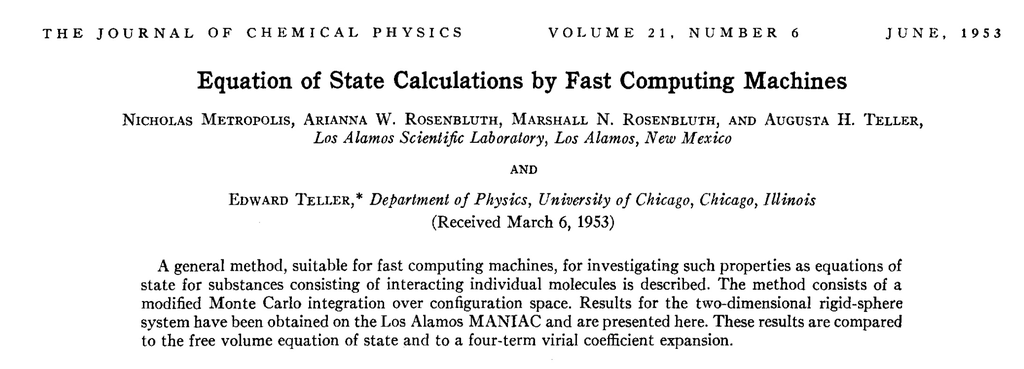

# Monte Carlo Sampling?

.pull-left[ - Monte Carlo sampling, typically Metropolis-Hastings algorithms, give us a large sample from the posterior distribution.

- From here we need to derive things like posterior mean, standard deviation, confidence intervals, etc.
- R packages can solve a lot, but some knowledge of the algorithms is need. ] .pull-right[

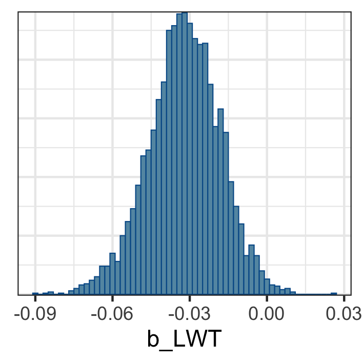

  ]

# (c) Check traceplot

It should look random, like this.

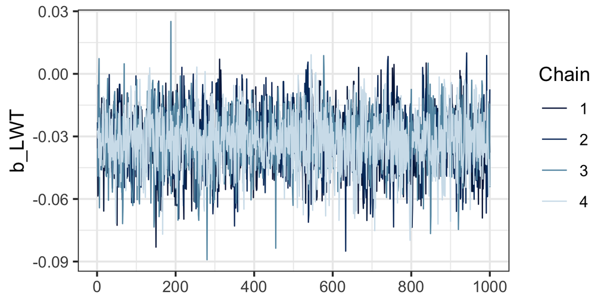

# (c) Check traceplot

And rather not like this. Algorithm gets stuck at each random number.

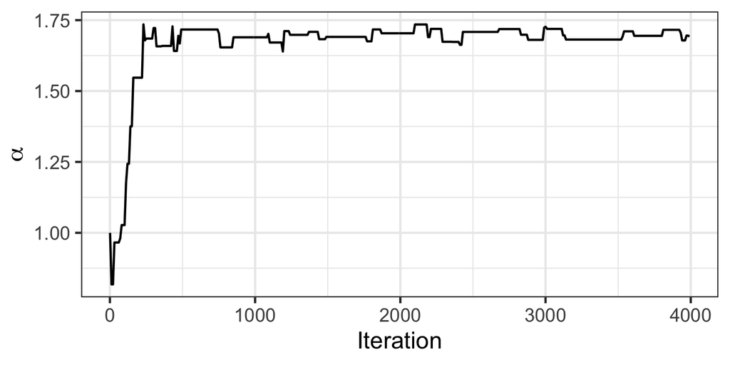

# (c) Check that the computations work correctly

Other things you might have to consider:

- R-hat
- Autocorrelation
- Effective sample size
- Divergent transitions

# (d) Check that the model fits the data well

- If the model fits the data well, simulating new observations from the model should give values close to the real data.

# Posterior predictive check 1

When re-generating 100 random datasets with same weight of mother, using the estimated posterior distribution of $\beta_{LWT}$, are the proportions of low birthweight children comparable?

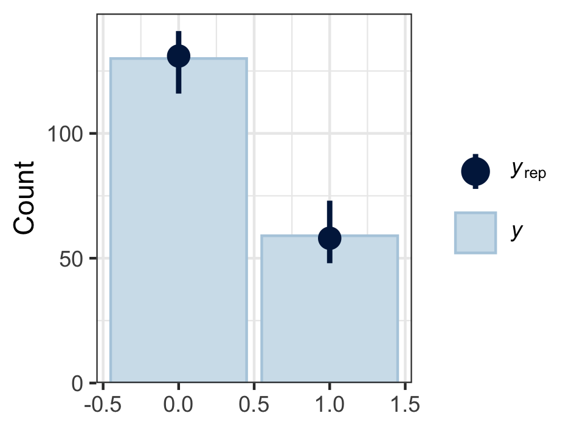

# Posterior predictive check 2

Logistic regression predicts the probability. Is the a relationship between the predicted probability and the error rate?

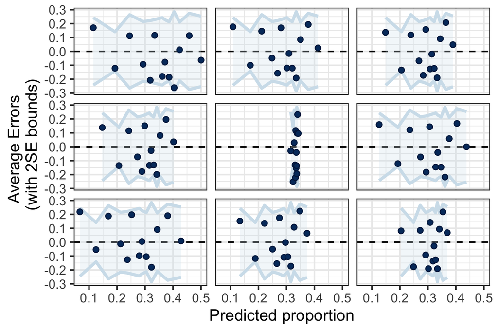

class: inverse, middle, center

# Predictive checks passed!

Next a little reminder

# Phases of a Statistical Workflow

1. Exploratory data analysis to aid in choosing initial model.
2. Quantify prior knowledge.
3. Check that the computations work correctly.
4. Check that the model fits the data well.

**(e) Compare to other more or less complicated models.**

.footnote[Gabry, J., Simpson, D., Vehtari, A., Betancourt, M., & Gelman, A. (2019). Visualization in Bayesian workflow. Journal of the Royal Statistical Society: Series A (Statistics in Society), 182(2), 389–402. https://doi.org/10.1111/rssa.12378]

# (e) Compare to other more or less complicated models

Let’s add smoking status:

$$P(Low) = \text{logit}\left(\beta_{0} + \beta_{LWT} \text{LWT} + \beta_{S} \text{Smoker}\right)$$

You’ll work through the prior for $\beta_{S}$ later.

# (e) Compare to other more or less complicated models

A common way of comparing models is to assess how well they predict new data. Cross-validation and Akaike information criterion are ways of assessing this.

Bayesian twists here as well:

- Widely Applicable Information Criterion (WAIC)
- Pareto smoothed importance sampling leave-one-out cross-validation (PSIS-LOO CV)<sup>1</sup>

.footnote[<sup>1</sup> Try to say that loud.]

# WAIC

```
## Output of model 'LWT':
##
## Computed from 4000 by 189 log-likelihood matrix
##
##           Estimate   SE
## elpd_waic   -116.5  5.6
## p_waic         2.2  0.3
## waic         233.0 11.3
##
## Output of model 'LWT+Smoker':
##
## Computed from 4000 by 189 log-likelihood matrix
##
##           Estimate   SE
## elpd_waic   -115.3  5.8
## p_waic         3.1  0.3
## waic         230.6 11.7
##
## Model comparisons:
##            elpd_diff se_diff
## LWT+Smoker  0.0       0.0
## LWT        -1.2       2.2
```

# LOO

```
##      elpd_diff se_diff
## mod2  0.0       0.0
## mod  -1.2       2.2
```

class: center, middle

# Thanks!

Slides created via the R package [**xaringan**](https://github.com/yihui/xaringan).

The chakra comes from [remark.js](https://remarkjs.com), [**knitr**](https://yihui.org/knitr/), and [R Markdown](https://rmarkdown.rstudio.com).